# 120 years of Olympics

Jo Hardin

7/27/2021

## Caveat

I’ve tried for a long time now to get the SVM to run on these data. I recognize that there isn’t a lot of signal here to predict winners! I think the lack of signal is what is keeping the model from converging. The code / steps below seem to be correct, but the file won’t knit, even after many hours. I’ll try SVMs again in a future week where maybe there *is* more signal!

## The Data

The data this week comes from [Kaggle](https://www.kaggle.com/heesoo37/120-years-of-olympic-history-athletes-and-results?select=noc_regions.csv).

> This is a historical dataset on the modern Olympic Games, including all the Games from Athens 1896 to Rio 2016. I scraped this data from www.sports-reference.com in May 2018. The R code I used to scrape and wrangle the data is on GitHub. I recommend checking my kernel before starting your own analysis.

```r
olympics <- read_csv("olympics.csv") %>%
  mutate(win = ifelse(is.na(medal), "no", "yes")) %>%
  mutate(country = case_when(
    noc == "USA" ~ "USA",
    noc == "FRA" ~ "FRA",
    noc == "GBR" ~ "GBR",
    noc == "ITA" ~ "ITA",
    noc == "GER" ~ "GER",
    noc == "CAN" ~ "CAN",
    noc == "JPN" ~ "JPN",
    noc == "EUN" ~ "RUS",
    noc == "RUS" ~ "RUS",
    noc == "URS" ~ "URS",
    noc == "BUL" ~ "BUL",
    TRUE ~ "other"
  ))
```

## The model

In my ongoing pursuit to understand tidymodels, I’m going to use a support vector machine to predict whether or not a medal was won. I’m finally starting to get the hang of the `tidymodels` structure:

- test / train / folds
- specify the model
- feature engineering (called recipe)
- workflow = model + recipe
- fit (on train or on CV data)

Does the model includes parameters that need to be tuned, then the flow is slightly different:

- test / train / folds
- specify the model **without** any parameter values (set them to `tune()`)
- feature engineering (called recipe) (same as above)
- workflow = model + recipe
- tune_grid (like fit, but across all CV folds and full parameter grid)
- fit (on CV data)

Notice that most people / teams don’t win. But with 40,000 winning observations, we should be able to fit a good model. Unfortunately, SVMs are really slow, so I can’t run the model on the full dataset. Instead, I’m taking a much smaller random sample.

```r
olympics %>%
  count(win)
```

```
## # A tibble: 2 × 2
##   win        n
##   <chr>  <int>
## 1 no    231333
## 2 yes    39783
```

Let’s look at the information contained in the data about winning over time. Notice the trick for empty bars at the ends (and the modular arithmetic to get bins of size 12).

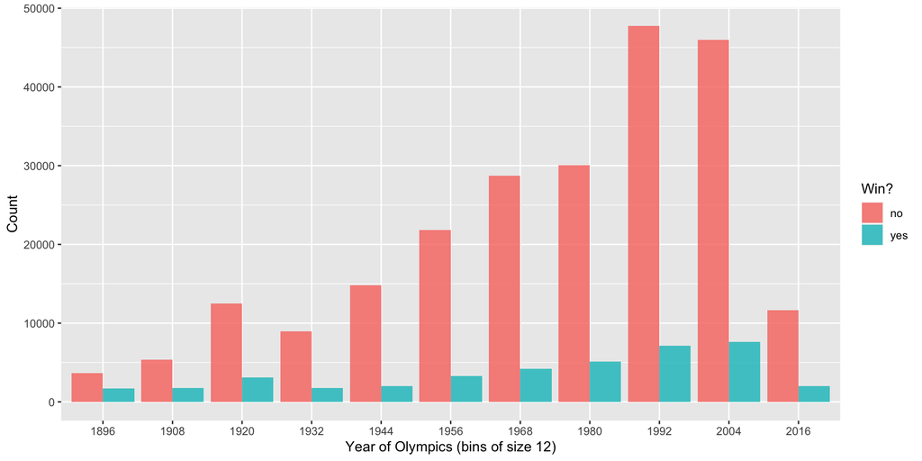

```r
olympics %>%
  count(
    year12 = 12 * ((year + 1) %/% 12),
    win
  ) %>%
  mutate(year12 = factor(year12)) %>%
  ggplot(aes(x = year12, y = n, fill = win)) +
  geom_col(position = position_dodge(preserve = "single"), alpha = 0.8) +
  labs(x = "Year of Olympics (bins of size 12)", y = "Count", fill = "Win?")
```